# Exercise One

Estimation by Monte-Carlo Simulation in R

#### Expectation of a Random Variable

- The expectation a discrete Random Variable $Y$ is:
  $$\mathbb{E}[Y] = \sum_{y} y \, p_Y (y) \approx \frac{1}{M} \sum_{i=1}^M y^{(m)} = \bar{y}$$
  where each $y^{(m)}$ from $1$ through $M$ is distributed $p_Y (y)$.
- The expectation of a continuous Random Variable $Y$ is:
  $$\mathbb{E}[Y] = \int_{y} y \, {p}_{Y}(y) \, dy \approx \frac{1}{M} \sum_{i=1}^M y^{(m)} = \bar{y}$$
  where each $y^{(m)}$ from $1$ through $M$ is distributed $p_Y (y)$.

##### Sampling from a discrete random variable: rolling a fair 6-sided die

One roll of a six-sided die can be modeled as a Random Variable $Y_D6$ which has one of six possible values in, { 1,…,6 }, each of which has probability $1/6$.

The R function `sample` takes arguments:

- `x` - either a vector of elements from which to sample or an integer $n$ in which case $x$ is the vector of integers $1:n$.
- `size` - a positive integer which specifies the number of items to choose
- `replace` - either `TRUE` or `FALSE` specifies whether sampling with/without replacement, default is `FALSE`.

Simulate one roll of a fair six-sided die (“D6”):

```
sample(c(1:6), 1);
 [1] 3
```

To simulate 10 independent rolls of a D6, `replace` should be set to `TRUE`:

```
sample(c(1:6), 10, replace=TRUE);
 [1] 6 6 5 2 4 3 4 3 6 5
```

Simulate 100 values:

```
> sample(c(1:6), 100, replace=TRUE)
[1] 4 3 3 6 1 2 1 3 2 2 6 1 1 5 2 6 2 4 1 6 2 5 6 3 4
    5 4 1 4 3 4 3 2 2 4 1 4 4 5 2 6 5 4 1 3 5 3 2 4 1
    3 1 2 2 6 6 4 6 5 1 1 2 5 4 5 1 5 1 5 2 5 1 5 4 6
    5 2 6 2 6 3 1 2 6 1 4 2 4 4 4 6 5 1 4 3 4 4 6 1 2
```

**Exercise 1.1**: Compute the expectation of the discrete RV $Y_{D6}$, one roll of a fair six-sided die using a sample of 100, 1000, and 10,000 draws, respectively.

##### Sampling from a continuous random variable: the Normal distribution.

Plots of the probability density function show a symmetric “bell curve” centered on the mean whose height/width is determined by the standard deviation.

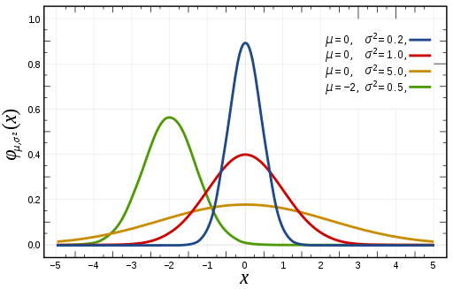

The R function `rnorm` generates a sequence of random draws from a normal distribution with a specified mean and standard deviation:

Take one draw from a normal distribution with mean 5, standard deviation 10:

```
rnorm(1, mean=5, sd=10)
[1] 12.07875
```

Take 100 draws:

```
rnorm(100, mean=5, sd=10)
  [1]  14.8462947   8.0735792   2.4734157   7.6774951  -0.2073813   4.9606262   3.6510407  12.8835495
  [9]   5.6449032  22.8583381   2.7765726   5.0189006 -10.6783155  -0.3498541   1.8920707  23.4656587
 [17]  13.0086797   1.6940446   7.6245823   0.1356268   3.6677676 -12.4893873  15.6051132   0.8198043
 [25]  29.8099277   1.5086770  17.8460684  -7.0311548 -11.9051549  17.6974229   4.9505833  -6.8014745
 [33]  -4.2759833  -1.5289839  -1.2261375   5.1040920  27.4643456  -4.3950494  -5.1456122  -3.7409858
 [41]  21.0609330  -0.3272468   0.5560233  10.1796741  12.7950104  22.9025000   1.2499491  -4.7077668
 [49]   8.9663284 -14.3782372 -16.8933651   6.3258832  18.7200482   7.1013480  -7.2355715  13.1030800
 [57]  -2.0957482   4.3703866   1.8779873  21.4730634   6.4950266 -13.1762963  13.1514351   9.0616678
 [65] -12.8618908   3.8085431   1.0981333   6.9481642  16.9777193  14.3057281  16.1671721   1.4471080
 [73]   2.5653629  17.6422668   5.1011498  17.5863671   9.5020089  17.9404970  18.2373002   5.0611401
 [81]   3.2828250  35.6020802   3.0981154   1.7111767  -5.2415036  19.8766368   9.5519978   1.6051318
 [89]   1.6079017  -6.4268732  15.4876133  19.2577546  15.7550100  15.0751943   4.1478186  10.5754150
 [97]   8.7662413  -6.8411017  16.2789227  -4.3084518
```

You can use R’s `hist` function to plot the sample distribution: `hist(rnorm(100, mean=5, sd=10), xlim=c(-35, 45))` - does this look like a bell curve?

**Exercise 1.2**: Compute the expectation of the continuous RV $Y$ which has a normal distribution of mean=5 and standard deviation=10, using a samples of 100, 1000, and 10,000 draws, respectively.

#### Variance of a Random Variable

The Variance of a Random Variable is the expectation of the squared difference of the value of the random variable from its mean:

$$\mathrm{var}[Y] = \mathbb{E}[ { \left( Y - \mathbb{E}[Y] \right) }^2 ]$$

- For a discrete Random Variable $Y$, the variance $\mathrm{var}[Y]$ is:
  $$\mathrm{var}[Y] = \sum_y {\left( y - \bar{y}\right)}^2 p_Y (y) \approx \frac{1}{M} \sum_{i=1}^M {\left( y^{(m)} -\bar{y} \right) }^2$$
  where each $y^{(m)}$ from $1$ through $M$ is distributed $p_Y (y)$.
- For a continuous Random Variable $Y$, the variance $\mathrm{var}[Y]$ is:
  $$\mathrm{var}[Y] = \int_y {\left( y - \bar{y}\right)}^2 p_Y (y) \, dy \approx \frac{1}{M} \sum_{i=1}^M {\left( y^{(m)} -\bar{y} \right) }^2$$
  where each $y^{(m)}$ from $1$ through $M$ is distributed $p_Y (y)$.

**Exercise 1.3**: Compute the variance of the discrete RV $Y_{D6}$, one roll of a fair six-sided die using a sample of 100, 1000, and 10,000 draws, respectively.

**Exercise 1.4**: Compute the variance of the continuous RV $Y$ which has a normal distribution of mean=5 and standard deviation=10, using a samples of 100, 1000, and 10,000 draws, respectively.